# Missing Data

Kim Johnson

April 12, 2018

## Learning objectives

1. Understand what missing data is
2. Understand why it can potentially be a big deal
3. Learn how to do multiple imputation in R using the MICE package

## What is the big deal with missing data?

- What do we care about in epidemiology and biostatistcs?
- Why can’t we just exclude all the people with missing data, do our analysis, and publish our results?
- BIAS and potentially BAD SCIENCE!!

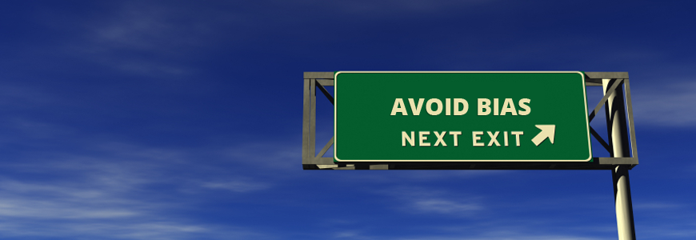

## A simple example

- What do you notice about the pattern of missing data?
- What happens if we elimate observations with missing data?
- How is the OR biased in the data with the eliminated observations relative to the unobserved dataset?

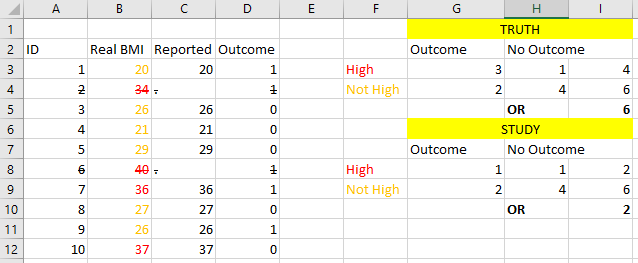

## Donald B. Rubin - the pioneer on thinking of missing data

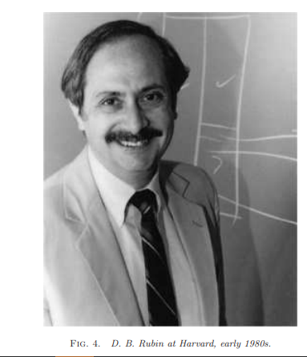

## A bit of history - a seminal paper

- Missing data seminal paper published in 1976 by Donald B. Rubin (Biometrika 1976)

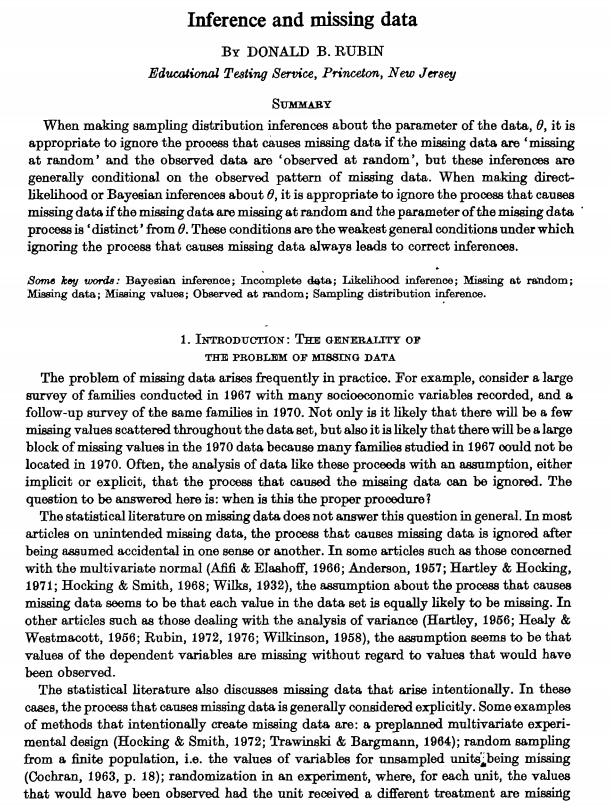

## A bit of history - a seminal book

[figure not shown]

## Here is what Dr. Rubin says in that book:

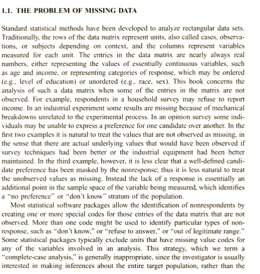

## Missing data types

- **Missing completely at random (MCAR)**
  - Missing value for variable y depends neither on x or y
  - Example some questions are asked of a random sample of survey respondents
- **Missing at Random (MAR)**
  - Missing value for variable y depends on x but not on the value of the variable y
  - Example males are less likely to report BMI than females
  - Depends only on observed data and not on unobserved data (so we can account for it)
- **Missing Not at Random (MNAR) or Not Missing at Random (NMAR)**
  - Probability of missing for a variable depends on the variable value
  - In other words missing data depends on the value
  - Example people with higher BMIs are less likely to report BMI and these people are more likely to develop the outcome

## Effects of missing data

- MCAR-loss of statistical power but unbiased estimates of effect
- MAR-unbiased parameter estimates when imputation is conducted
- MNAR-biased parameter estimates

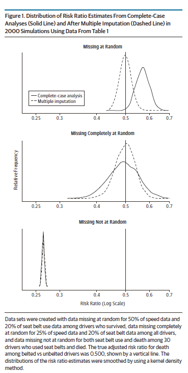

## What characteristics should a solid method of dealing with missing data have?

- *from J. Graham, Annu. Rev. Psychol. 2009. 60:549-576*
1. The method should yield unbiased parameter estimates (should be close to population value)
2. There should be a method for assessing the degree of uncertainty in the estimates (i.e. should account for missingness in standard errors and confidence intervals)
3. The method should have good statistical power

## Ways to deal with missing data

- Mean substition (*do not use*): Substitute missing values with mean of the distribution for the variable
- Listwise deletion (Complete case analysis)(*Use with caution*): only include people with data on all variables
- Pairwise deletion (Available case analysis)(*do not use*): individual data still included in calculations of correlations if they have values for at least one of the variables
- Code individuals with a missing value on a variable into a missing category (*do not use*)
- Single imputation: impute missing values for a variable one at a time (*do not use*)
- **multiple imputation**: Impute a plausible **set** of missing values that cover the range of uncertainty of possible values (*Use!!*)

## The MICE (multivariate imputation by chained equations) in R

- Multiple imputation is the method of choice for missing data
- “To the uninitiated, multiple imputation is a bewildering technique that differs substantially from conventional statistical approaches. As a result, the first-time user may get lost in a labyrinth of imputation models, missing data mechanisms, multiple versions of the data, pooling, and so on.” (from Buuren and Groothuis-Oudshoorn, 2011)

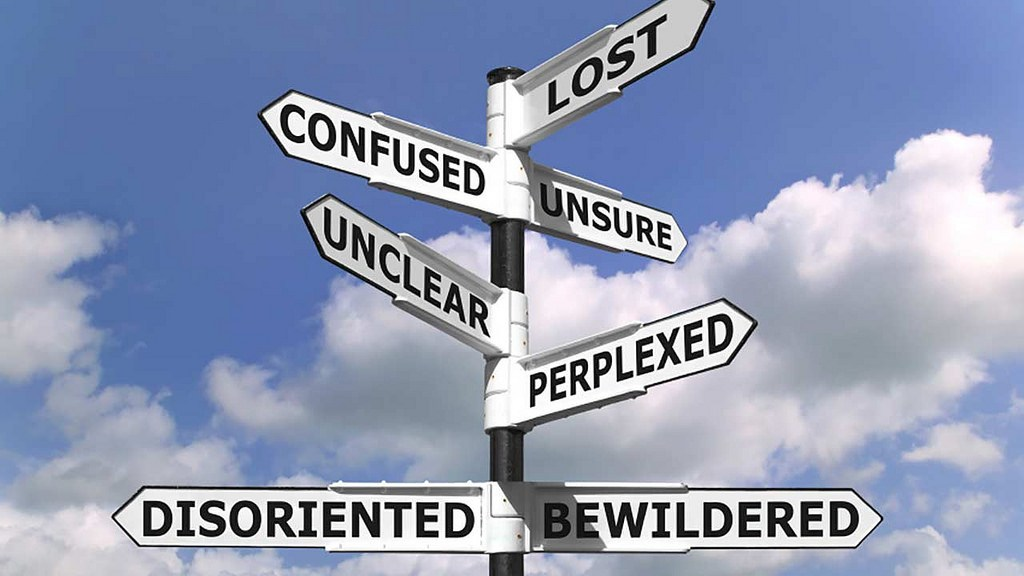

## Using the MICE package in R

- Helps you impute missing data with *plausible* values
- Drawn from the distribution of values customized for each missing data point

## What it does (3 steps)

1. Generates **n** number of datasets with imputed values for missing data
2. Analyze data using these datasets
3. Pooling estimates and standard errors to get pooled B’s and SEs

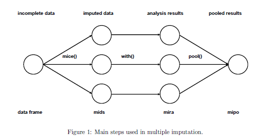

- The three imputed datasets shown in the figure are the same for non-missing values and differ for missing values. The magnitude of this difference represents the uncertainty in the imputed values with respect to the real unknown/unobserved value. The imputed values are calculated by chained equations, which is beyond the scope of this course. To read more: https://www.ncbi.nlm.nih.gov/pmc/articles/PMC3074241/
- Next, we use our standard regression models to estimate the parameter of interest from each of the imputed datasets.
- Finally, we pool the parameter estimates and their SEs using what is referred to as *Rubin’s rules* to get a single imputed parameter estimate.

## What the imputation model should do (another way of characterizing a solid method for dealing with missing data)

- Accounts for the process that created the missing data
- Preserves the relations in the data
- Preserves the uncertainty about these relations
- Multiple imputation does all of this! Caveat: We are still uncertain about bias in parameter estimates for data MNAR but we can test assumptions.

## If imputations are not done correctly, what can happen (among other less obvious things)?

- Can create impossible combinations (e.g. pregnant fathers)
- Imputations can be nonsensical (e.g. body temperature of the dead)

## Let’s see how this works using the R MICE (Multiple Imputation by Chained Equations) package and the NHANES dataset that is provided with the package.

```r
#install.packages("mice") #Install mice package for imputed missing data
#install.packages('VIM') #Install VIM package for plotting missing data patterns
library(VIM)
library(mice)
library(lattice)
```

## load builtin NHANES data to look at NAs

```r
nhanes
```

```
##    age  bmi hyp chl
## 1    1   NA  NA  NA
## 2    2 22.7   1 187
## 3    1   NA   1 187
## 4    3   NA  NA  NA
## 5    1 20.4   1 113
## 6    3   NA  NA 184
## 7    1 22.5   1 118
## 8    1 30.1   1 187
## 9    2 22.0   1 238
## 10   2   NA  NA  NA
## 11   1   NA  NA  NA
## 12   2   NA  NA  NA
## 13   3 21.7   1 206
## 14   2 28.7   2 204
## 15   1 29.6   1  NA
## 16   1   NA  NA  NA
## 17   3 27.2   2 284
## 18   2 26.3   2 199
## 19   1 35.3   1 218
## 20   3 25.5   2  NA
## 21   1   NA  NA  NA
## 22   1 33.2   1 229
## 23   1 27.5   1 131
## 24   3 24.9   1  NA
## 25   2 27.4   1 186
```